# El chocolate

MVAP, MVAP2, MVAP3

2024-11-19

## Intruducción

### 1.1 El chocolate

El **chocolate** (del náhuatl, *xocoatl*)[^1] [^2] es el alimento que se obtiene mezclando azúcar con dos producto**<sub>s</sub>** que derivan de l**<sup>a</sup>** manipulación de las semillas del cacao: la masa del cacao y la manteca de cacao. A partir de esta combinación básica se elaboran los distintos tipos de chocolate que dependen de la proporción entre estos elementos y de su mezcla, o no, con otros productos ya sea como leche, colorante, y/o frutos secos (Kiss et al. 2024).

En 1896 El famoso gastrónomo francés J. A. Brillat-Savarin definió chocolate de la siguiente manera

> “Se ha convenido en dar el nombre de chocolate a la mezcla compuesta de la semilla del árbol del cacao tostada, que lleva azúcar y canela; tal es la definición clásica del chocolate. El azúcar forma parte integrante, porque con cacao sólo resulta únicamente pasta de cacao y no chocolate.”

### 1.2 Los datos

Los datos de este proyectos fueron descargados desde [kaggle](https://www.kaggle.com). Participaron 416 compañias fabricantes de cocholate y se incluyeron chocolates de 100 paises diferentes.

Tabla 1: Diez primeras filas

| Company..Maker.if.known. | Specific.Bean.Origin.or.Bar.Name | REF | Review.Date | Cocoa.Percent | Company.Location | Rating | Bean.Type | Broad.Bean.Origin |
| --- | --- | --- | --- | --- | --- | --- | --- | --- |
| A. Morin | Agua Grande | 1876 | 2016 | 63% | France | 3.75 |  | Sao Tome |
| A. Morin | Kpime | 1676 | 2015 | 70% | France | 2.75 |  | Togo |
| A. Morin | Atsane | 1676 | 2015 | 70% | France | 3.00 |  | Togo |
| A. Morin | Akata | 1680 | 2015 | 70% | France | 3.50 |  | Togo |
| A. Morin | Quilla | 1704 | 2015 | 70% | France | 3.50 |  | Peru |
| A. Morin | Carenero | 1315 | 2014 | 70% | France | 2.75 | Criollo | Venezuela |
| A. Morin | Cuba | 1315 | 2014 | 70% | France | 3.50 |  | Cuba |
| A. Morin | Sur del Lago | 1315 | 2014 | 70% | France | 3.50 | Criollo | Venezuela |
| A. Morin | Puerto Cabello | 1319 | 2014 | 70% | France | 3.75 | Criollo | Venezuela |
| A. Morin | Pablino | 1319 | 2014 | 70% | France | 4.00 |  | Peru |

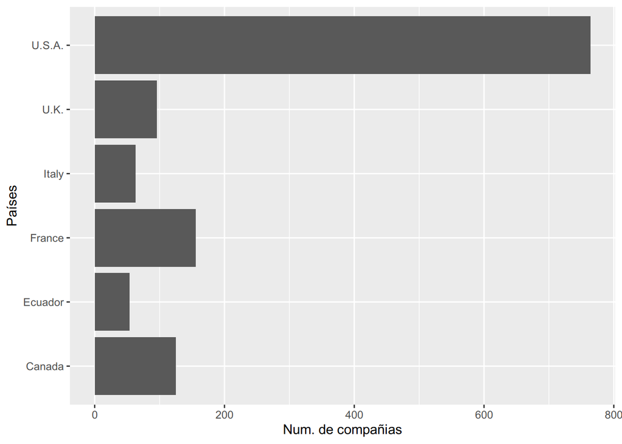

Fig 1. Paises top productores de barras de chocolate

### 1.3 Hipótesis

Nuestra hipótesis es que cuanto mayor es el porcentaje de cacao mayor es el rating.

## Resultados

[figure not shown]

## Conclusiones

Los datos no apoyan nuestra hipótesis.

## Información de la sesión y referencias

Kiss, Tibor, Zoltán Karácsony, Adrienn Gomba-Tóth, Kriszta Lilla Szabadi, Zsolt Spitzmüller, Júlia Hegyi-Kaló, Thomas Cels, et al. 2024. “A Modified CTAB Method for the Extraction of High-Quality RNA from Mono-and Dicotyledonous Plants Rich in Secondary Metabolites.” *Plant Methods* 20 (1): 62. https://doi.org/10.1186/s13007-024-01198-z.

R Core Team. 2024. *R: A Language and Environment for Statistical Computing*. Vienna, Austria: R Foundation for Statistical Computing. https://www.R-project.org/.

Wickham, Hadley. 2016. *Ggplot2: Elegant Graphics for Data Analysis*. Springer-Verlag New York. https://ggplot2.tidyverse.org.

Wickham, Hadley, Winston Chang, Lionel Henry, Thomas Lin Pedersen, Kohske Takahashi, Claus Wilke, Kara Woo, Hiroaki Yutani, Dewey Dunnington, and Teun van den Brand. 2024. *Ggplot2: Create Elegant Data Visualisations Using the Grammar of Graphics*. https://ggplot2.tidyverse.org.

Wickham, Hadley, Romain François, Lionel Henry, Kirill Müller, and Davis Vaughan. 2023. *Dplyr: A Grammar of Data Manipulation*. https://dplyr.tidyverse.org.

[^1]: Hernández Triviño, Ascensión (2013-12). «Chocolate: historia de un nahuatlismo». Estudios de cultura náhuatl 46: 37-87. ISSN 0071-1675. Consultado el 7 de marzo de 2021.
[^2]: Real Academia Española. «chocolate». Diccionario de la lengua española (23.ª edición).